# Prevention versus Prediction

Raymond Santiago Flores | STAT 3280 | Spring 2026

May 7, 2026

# Part 1: Context

## Background

Armed conflict is a persistent force shaping human history, its patterns evolving but never truly vanishing. In the modern era, global instability and violence continue to surge, demanding not only attention but a deeper understanding. This project investigates the dynamics of armed conflict from 1946 to 2024, leveraging integrated datasets from the Uppsala Conflict Data Program and the Peace Research Institute Oslo (UCDP/PRIO). As the world grows increasingly interconnected, both the frequency and complexity of conflict escalate, and reliable information becomes a critical resource. By visualizing regional trends and distilling complex data into accessible insights, this project aims to equip policymakers, researchers, and the public with a clearer picture of how conflict unfolds. The merged UCDP/PRIO datasets enable an exploration of historical patterns, drivers, and consequences of war—covering everything from recorded deaths and peace agreements to the underlying triggers of violence. Advanced data visualization brings these dynamics to life.

## Where conflict happens — Hotspots, 1946–2024

This map reveals a stark truth: armed conflict has been a constant presence from 1946 to 2024. Every marker you see on the map represents real wars—lives lost, societies changed. The larger the marker, the more conflicts occurred in that country in a given year; the color separates wars from smaller-scale violence. Use the time slider to watch how conflict moves and intensifies.

[figure not shown]

Fig 1: Each hotspot tells a story of unresolved tensions, power struggles, and the human cost of instability. The geographic distribution acts as the spatial signature of structural and political conditions.

## What kind of conflict — and at what cost

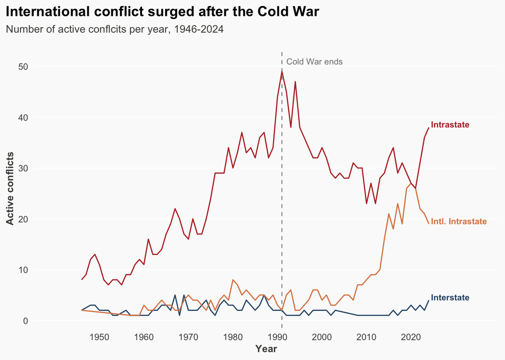

Figure 2.

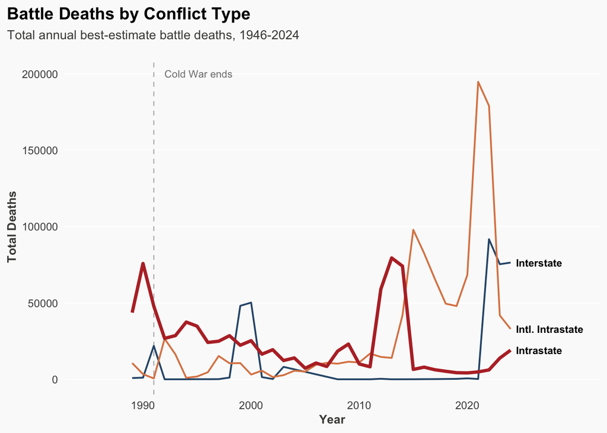

Figure 3.

The count of active conflicts, as mentioned, is a two-part story: the types of conflicts present and their escalation patterns. In this context, it’s important to briefly define the main types of conflict:

- **Intrastate conflicts** are civil wars fought within a single country, usually between a government and internal opposition groups.
- **Internationalized intrastate conflicts** also take place within one country, but foreign states get involved by supporting one of the sides.
- **Interstate conflicts** are wars fought between the recognized governments of two or more different countries.

## Why people fight — Ideology, geography, religion

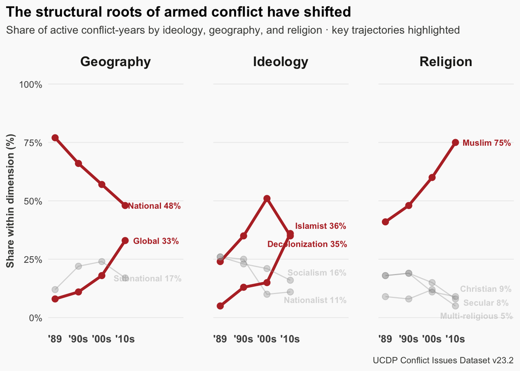

Figure 4.

Ideology, geography, and religion depict the underlying logic of conflict. As they depict a telling story of the reasons for conflict over time. The next question is human arithmetic, and how the shift towards intrastate and internationalized war has not only changed the number of deaths, but also who bears them. These distinctions in conflict type and death toll reflect structural conditions, but they do not explain the underlying logic — what drives groups to fight, and to keep fighting for years or decades. The answer lies in what conflicts are actually about: the ideologies, territorial claims, and identity grievances that give violence its staying power.

## The Cost

The chart below breaks that toll down by party, separating deaths among government forces, armed groups, and civilians across each decade since 1980.

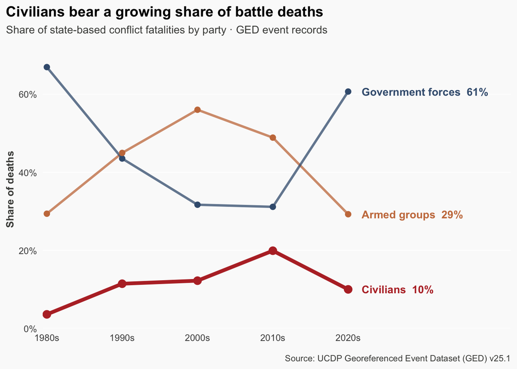

Figure 5.

## How outsiders shape the way wars end

[figure not shown]

```javascript
var divElement = document.getElementById('viz1778209707050');
var vizElement = divElement.getElementsByTagName('object')[0];
vizElement.style.width = '100%';
vizElement.style.height = '500px';
var scriptElement = document.createElement('script');
scriptElement.src = 'https://public.tableau.com/javascripts/api/viz_v1.js';
vizElement.parentNode.insertBefore(scriptElement, vizElement);
```

Fig 7. The geographic snapshot is striking, but it conceals a deeper structural shift. To see it, we need to ask not *where* — but *what kind* of conflict has come to dominate.

Conflicts rarely play out among local actors alone. Foreign powers send weapons, fund factions, deploy troops, or look the other way. The pattern is consistent across types: external involvement pushes the outcome distribution away from decisive ends (peace agreements, victories) and toward stalemate or ambiguity (ceasefires, low activity). But the outcome distribution only tells part of the story. Before a conflict reaches any ending — clean or ambiguous — time passes. The question of how much time, and whether outside involvement changes that, is what the next two figures address.

## Length

[interactive chart not shown]

Figure 8.

The scatter plot captures each conflict’s position at the recorded moment of termination. Visualizing where the data clusters indicate that externally supported conflicts, on average, last longer. To see how the external-support effect compounds over time, the survival curve below tracks the share of episodes still active at each year since onset.

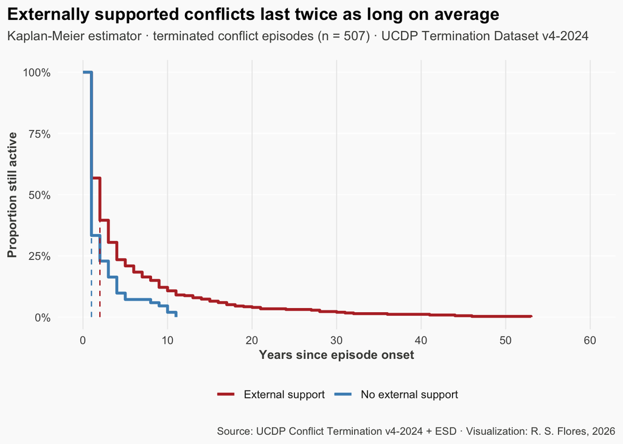

Figure 9.

To visualize and test whether externally supported conflicts lasted longer on average, a survival analysis mechanism was employed. Above is a Kaplan-Meier curve plot. Tracking the duration of the last observances of the conflicts observed. From this, we can identify that the duration gap is driven by multiple mechanisms. Since external support takes many forms, results vary systematically, a direct implication of the variability of outside intervention and its effects on how conflicts unfold. To understand why the effect varies, we need to look inside the category of external support itself. Not all intervention is the same — troops, money, weapons, and sanctuary each carry different implications for how long a conflict can be sustained.

## External Support Breakdown

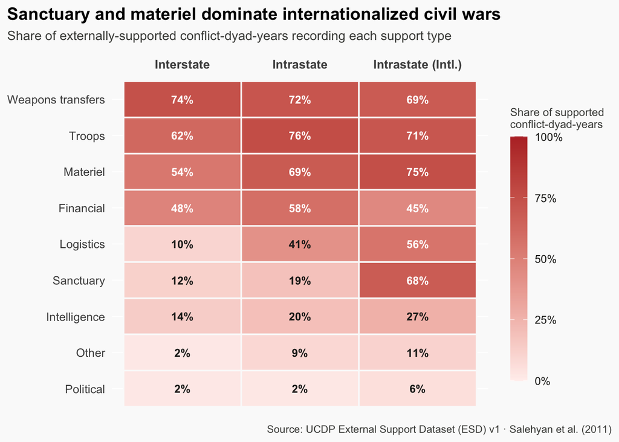

Figure 10.

These nine dimensions of external support — and the conflict types they attach to — do not operate in isolation. They compound: a conflict with financial backing and sanctuary is structurally different from one receiving only political recognition. The interactive dashboard below lets you explore how these variables interact across time, region, and conflict type.

## Application 1

Exploring the behavior of different demographics is a powerful tool for understanding the underlying systematic behavior across the dense domains of these datasets. To facilitate this understanding, an interactive dashboard was created to apply further understanding and explore these global relationships.

The dashboard has five tabs, all linked to the filters on the left. Use Temporal scope to restrict the time window, Focus region to isolate a continent, and Conflict type to include or exclude categories — the default shows intrastate wars only, where the post-Cold War surge is most visible. The Temporal Heatmap gives an at-a-glance view of activity density by year and type. Fatality Distribution shows the log-scale spread of battle deaths — note the long right tail of catastrophic outliers. Conflicts Over Time traces annual counts with labeled end-points. The Survival (KM) tab shows Kaplan–Meier survivorship curves for terminated episodes: it responds to conflict type but not year or region, since episode duration is a property of the conflict record rather than a calendar filter. Dashed verticals mark the median duration for each support group. The Conflict List is a searchable table of every conflict matching the active filters.

[interactive chart not shown]

## Part 3: The path from cause to resolution

The first half of this project has traced the shape of conflict — where it happens, what drives it, who funds it, and how long it lasts. Part 3 turns to resolution: what the path from onset to termination actually looks like, and whether the patterns embedded in the data are strong enough to support prediction.

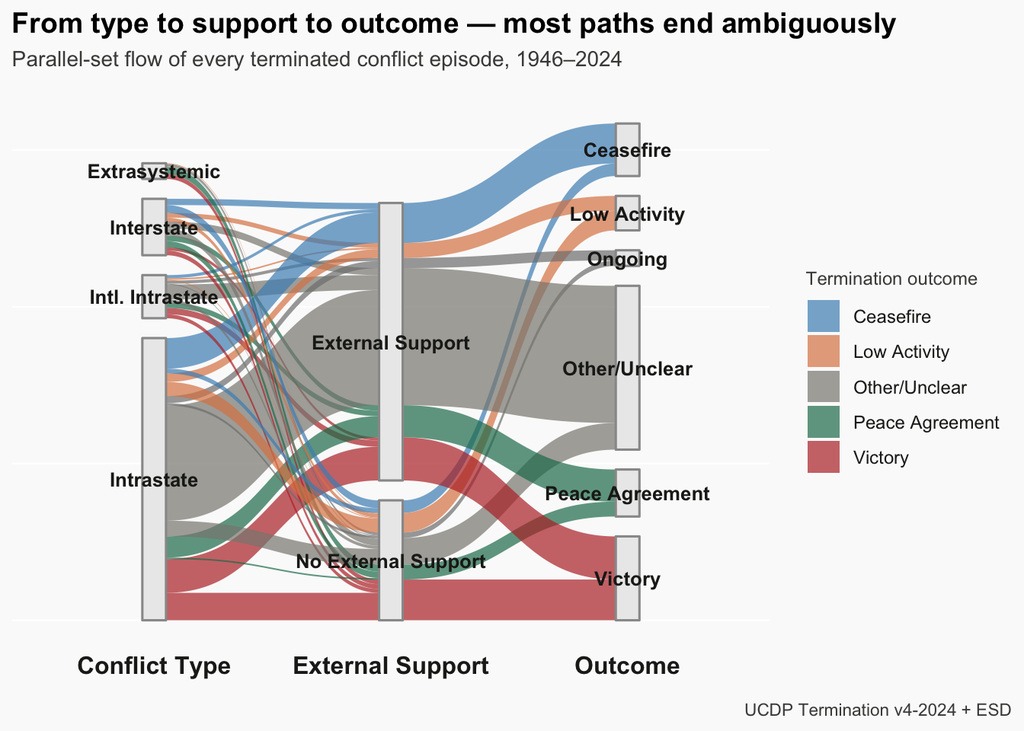

Figure 11.

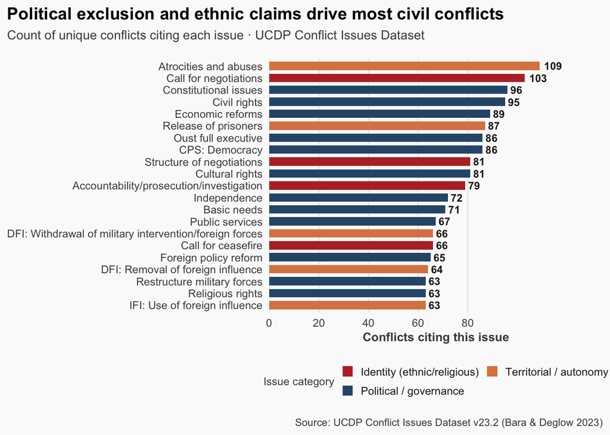

Figure 12.

The box plot below shows episode duration broken down by termination outcome, revealing that the path to a peace agreement is almost always the longest one.

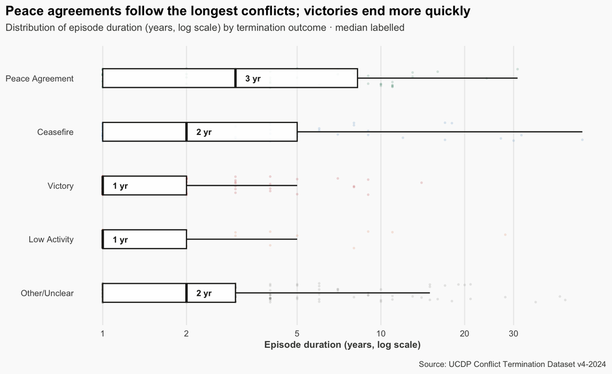

Figure 13. Box plot of episode duration by outcome.

## Understanding the Landscape of Peace

[figure not shown]

Figure 14.

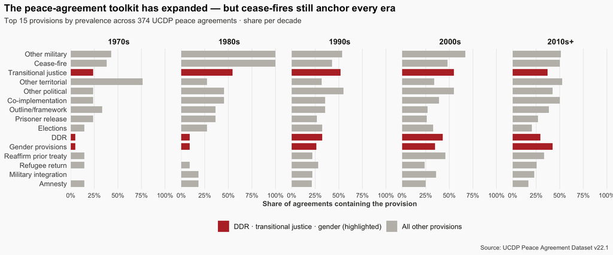

Figure 15.

## **Predicting Armed Conflict App**

In the final analysis, I built an interactive tool that uses a random forest model to explore what really drives conflict outcomes. The model draws on everything I’ve analyzed—conflict type, the duration of fighting, the role of outside supporters, and the main issues at stake. By training the model on a comprehensive set of past conflicts, I can show how each factor shapes the likelihood of war ending in peace, victory, or stalemate. The dashboard doesn’t just predict outcomes; it lets you see the weight of each element, making the patterns behind war’s end more transparent.

[interactive chart not shown]

Ultimately, what this project shows is that conflict isn’t random, and neither is its resolution. By breaking down the data and making these dynamics visible, we can move beyond headlines to grasp the forces that drive violence—and maybe, in understanding them, find clues for building something better.

## Sources & data documentation

**Datasets**

**Tools**

R 4.4 (tidyverse, ggplot2, plotly, ggforce, ggrepel, randomForest, WDI, vdemdata, shiny). Tableau Public for the geographic and bivariate-bar views. Typography: Lora (display) and Source Sans 3 (text), via Google Fonts.